# Habitual Media Diet: Level and Diversity Across Diet Definitions and Tracking Channels

Master’s Thesis – Media Quality / Media Diet

2026-09-12

```r
knitr::opts_chunk$set(echo = TRUE, eval = TRUE, warning = FALSE, message = TRUE)
```

# 1 Overview

Builds pre-treatment measures of habitual media-diet quality and diversity. Every construction step and every diagnostic runs once per combination of **tracking channel** and **diet definition**, so no logic is duplicated across variants and any difference between them reflects the data rather than an inconsistency between copy-pasted blocks.

Five things, in this order:

1. Fix a participant-specific reference date and a 30-day baseline window
2. Build level and diversity for every channel x diet combination
3. Add descriptive median splits, computed within each combination
4. Produce faceted plots and five design diagnostics across all combinations
5. Compare the diet definitions on coverage, variance, stability and sparsity

## 1.1 Two registries define everything below

**Tracking channel.** This replaces the previous second script, which was a full copy of this one differing in a single filter.

| Channel key | Rule | Purpose |
| --- | --- | --- |
| `with_apps` | All visit types | Primary measure; app traffic folded into publisher domains in `01d` |
| `without_apps` | `visit_type != 2` | Robustness: does app-derived traffic drive the picture |

**Diet definition.** The original `is_news` is never overwritten; `is_news_corrected` reflects the manual domain review from `01e`.

| Variant key | Visit filter | Main use |
| --- | --- | --- |
| `overall` | `pc1` available, no news restriction | Broad information-diet description |
| `news` | `is_news == TRUE` | Sensitivity check on the automated classification |
| `news_corrected` | `is_news_corrected == TRUE` | Primary news-specific measure |

All six combinations share the same reference date, window, activity rule and weighting logic. Only the visit-level filter differs.

## 1.2 Level and diversity

Level is the duration-weighted mean PC1 score: the average quality of a participant’s scored sources. Diversity is the duration-weighted standard deviation: how heterogeneous those sources are in quality. Two people can share an average and differ sharply in diversity, one using mid-quality sources consistently, the other alternating between high and low. The distinction follows media-diet work that treats the average position of a diet and its internal heterogeneity as separate constructs (Padro-Solanet & Balcells, 2022).

## 1.3 Design choices

| Choice | Rule | Reason |
| --- | --- | --- |
| Reference date | Day before each participant’s earliest search task | Guarantees the baseline precedes that participant’s first exposure |
| Baseline window | 30 calendar days | Recent and comparable; checked against full history in Diagnostic B |
| Activity threshold | At least 7 active days, counted on *all* baseline visits | Avoids treating sparse observation as habitual behaviour; the threshold describes overall browsing, not diet-specific browsing |
| Weighting | Visit duration | Longer visits contribute more |
| Diversity requirement | At least 2 distinct PC1 values | A spread statistic is not meaningful for a single score |
| Median splits | Computed within each channel x variant | The combinations have different distributions and different available samples |

## 1.4 Outputs

| Output | Level | Purpose |
| --- | --- | --- |
| `<channel_dir>/habitual_media_diet_FINAL.csv` | Participant (wide) | Variant-prefixed columns, one file per channel, read by `03b`–`03e` |
| `habitual_media_diet_long.csv` | Participant x channel x variant | Long format for plots and comparison |
| `MAIN_plot_*.png` | Faceted channel x variant | Core descriptive plots |
| `diagnostics/diagnostic_*.csv`, `diag*.png` | Participant / visit | Design checks A–E |
| `habitual_media_diet_variant_comparison.csv` | Channel x variant | Side-by-side comparison table |

In the wide file every measure carries a `hab_` prefix and its variant key, for example `hab_news_corrected_dw_pc1`. The prefix marks the measurement period: `hab_` for pre-treatment habitual measures built here, `exp_` for experimental-period exposures built in `03a`. Keeping the two families disjoint is what prevents the join collision documented in Appendix G. In the long file the names stay generic, with `channel` and `variant` columns carrying the keys.

# 2 Part 1: Setup

```r
library(dplyr)
```

```r
library(tidyr)
library(purrr)
library(ggplot2)
library(readr)
library(tibble)
```

```r
#project_root <- "DoesMediaQualityMatter"
#data_dir     <- ""
input_dir  <- file.path(project_root, "Output", "01_visits")
output_dir <- file.path(project_root, "Output", "02_media_quality")

# One directory per tracking channel, matching the existing folder names so
# downstream paths stay valid.
channel_dirs <- c(
  with_apps    = file.path(output_dir, "habitual_media_diet_baseline"),
  without_apps = file.path(output_dir, "habitual_media_diet_baseline_without_apps")
)
diagnostics_dir <- file.path(channel_dirs[["with_apps"]], "diagnostics")

walk(c(channel_dirs, diagnostics_dir), dir.create, showWarnings = FALSE, recursive = TRUE)

attitude_paths <- file.path(data_dir,
                            c("df1_final_ac.Rdata", "df2_final_ac.Rdata", "df3_final_ac.Rdata"))
```

```r
BASELINE_WINDOW_DAYS    <- 30
MIN_ACTIVE_DAYS         <- 7
MIN_ACTIVE_DAYS_FULL    <- 20
MIN_DISTINCT_PC1_FOR_SD <- 2

DATA_COLLECTION_START <- as.Date("2023-04-01")
WAVE1_START_FIXED     <- as.Date("2023-06-12")
```

## 2.1 Inputs

| Input | Level | Required variables |
| --- | --- | --- |
| `visits_final.Rds` | Visit | `pid`, `used_date`, `content_id`, `duration`, `visit_type`, `pc1`, `is_news`, `is_news_corrected` |
| `df1`–`df3_final_ac.Rdata` | Wave | `pid`, `start_time`, `sources_used` |

```r
visits <- readRDS(file.path(input_dir, "visits_final.Rds")) %>%
  mutate(
    pid = as.character(pid),
    used_date = as.Date(used_date),
    content_id = as.character(content_id),
    duration = as.numeric(duration),
    pc1 = as.numeric(pc1),
    is_news = as.logical(is_news),
    is_news_corrected = as.logical(is_news_corrected)
  )

waves <- map(attitude_paths, function(p) {
  e <- new.env(); load(p, envir = e)
  get(ls(e)[1], envir = e) %>%
    mutate(pid = as.character(as.numeric(pid)),
           search_start = as.POSIXct(start_time, format = "%Y-%m-%d %H:%M:%S", tz = "Europe/Berlin"))
})

tibble(
  visit_rows        = nrow(visits),
  participants      = n_distinct(visits$pid),
  with_pc1          = sum(!is.na(visits$pc1)),
  is_news           = sum(visits$is_news, na.rm = TRUE),
  is_news_corrected = sum(visits$is_news_corrected, na.rm = TRUE),
  app_rows          = sum(visits$visit_type == 2L, na.rm = TRUE)
)
```

```
## # A tibble: 1 × 6
##   visit_rows participants with_pc1 is_news is_news_corrected app_rows
##        <int>        <int>    <int>   <int>             <int>    <int>
## 1   16571723         1499   894316  381595            598750 12703690
```

## 2.2 Registries

The single place where the six combinations are defined. Everything below loops over `analysis_grid` rather than repeating code per combination. `flag_col = NA` means no news filter.

```r
channel_variants <- tribble(
  ~channel,        ~channel_label,           ~keep_apps,
  "with_apps",     "All channels",           TRUE,
  "without_apps",  "Web and mobile web only", FALSE
)

diet_variants <- tribble(
  ~variant,         ~flag_col,           ~variant_label,
  "overall",        NA_character_,       "Overall scored diet",
  "news",           "is_news",           "Automated news diet",
  "news_corrected", "is_news_corrected", "Corrected news diet"
)

channel_levels <- channel_variants$channel
variant_levels <- diet_variants$variant

analysis_grid <- cross_join(channel_variants, diet_variants)

# Visit-level data split by channel, used by every builder below.
visits_by_channel <- set_names(
  map(channel_variants$keep_apps, function(keep)
    if (keep) visits else filter(visits, visit_type != 2L)),
  channel_variants$channel)

map_dfr(names(visits_by_channel), ~ tibble(channel = .x, visit_rows = nrow(visits_by_channel[[.x]])))
```

```
## # A tibble: 2 × 2
##   channel      visit_rows
##   <chr>             <int>
## 1 with_apps      16571723
## 2 without_apps    3868033
```

# 3 Part 2: Reference Date and Baseline Window

Each participant’s baseline ends the day before their earliest recorded search task, which is what prevents post-treatment visits from entering a pre-treatment measure. The rule does not depend on channel or diet variant.

```r
pid_wave_search <- map_dfr(seq_along(waves), ~ waves[[.x]] %>%
                             transmute(pid, wave = .x, search_start)) %>%
  filter(!is.na(search_start)) %>%
  distinct(pid, wave, .keep_all = TRUE)

pid_windows <- pid_wave_search %>%
  group_by(pid) %>%
  summarise(reference_date = as.Date(min(search_start)) - 1, .groups = "drop") %>%
  mutate(window_start = reference_date - (BASELINE_WINDOW_DAYS - 1))

visits_baseline <- map(visits_by_channel, function(v)
  v %>% inner_join(pid_windows, by = "pid") %>%
    filter(used_date >= window_start, used_date <= reference_date))

map_dfr(names(visits_baseline), ~ tibble(
  channel = .x,
  baseline_rows = nrow(visits_baseline[[.x]]),
  participants = n_distinct(visits_baseline[[.x]]$pid)))
```

```
## # A tibble: 2 × 3
##   channel      baseline_rows participants
##   <chr>                <int>        <int>
## 1 with_apps          2741226          789
## 2 without_apps        728639          788
```

Descriptive only, used in no calculation: whether a participant reported using any source during a search task.

```r
pid_used_any_source <- map_dfr(seq_along(waves), ~ waves[[.x]] %>%
                                 transmute(pid, wave = .x, sources_used)) %>%
  distinct(pid, wave, .keep_all = TRUE) %>%
  group_by(pid) %>%
  summarise(used_any_source = if (all(is.na(sources_used))) NA
            else any(sources_used == 1, na.rm = TRUE), .groups = "drop")
```

# 4 Part 3: Constructing the Diet Measures

```r
weighted_mean_na <- function(x, w) {
  keep <- !is.na(x) & !is.na(w) & w > 0
  if (!any(keep)) return(NA_real_)
  sum(x[keep] * w[keep]) / sum(w[keep])
}

weighted_sd_na <- function(x, w) {
  keep <- !is.na(x) & !is.na(w) & w > 0
  x <- x[keep]; w <- w[keep]
  if (length(unique(x)) < MIN_DISTINCT_PC1_FOR_SD || sum(w) == 0) return(NA_real_)
  m <- sum(x * w) / sum(w)
  sqrt(sum(w * (x - m)^2) / sum(w))
}

# Subsets to a diet variant's visits and computes the five core statistics.
# Called once per grid row, so all six combinations share identical logic.
build_variant_activity <- function(flag_col, visits_df) {
  if (!is.na(flag_col)) visits_df <- visits_df[visits_df[[flag_col]] %in% TRUE, , drop = FALSE]

  visits_df %>%
    group_by(pid) %>%
    summarise(
      n_rows_with_pc1          = sum(!is.na(pc1)),
      n_distinct_pc1           = n_distinct(pc1[!is.na(pc1)]),
      pc1_duration             = sum(duration[!is.na(pc1)], na.rm = TRUE),
      duration_weighted_pc1    = weighted_mean_na(pc1, duration),
      duration_weighted_sd_pc1 = weighted_sd_na(pc1, duration),
      .groups = "drop"
    )
}
```

Active days, row counts and total duration describe overall baseline browsing and so depend on the channel but not on the diet variant. They gate every variant’s availability through the activity threshold.

```r
general_activity <- map_dfr(names(visits_baseline), ~ visits_baseline[[.x]] %>%
  group_by(pid) %>%
  summarise(n_active_days = n_distinct(used_date), n_rows = n(),
            total_duration = sum(duration, na.rm = TRUE), .groups = "drop") %>%
  mutate(channel = .x))
```

A participant absent from a combination’s activity table had zero qualifying visits for that combination, not a missing observation. The cross join below makes those structural zeros explicit before the coalesce.

```r
habitual_long <- analysis_grid %>%
  mutate(activity = map2(flag_col, channel,
                         ~ build_variant_activity(.x, visits_baseline[[.y]]))) %>%
  dplyr::select(channel, channel_label, variant, variant_label, activity) %>%
  unnest(activity)

habitual_long <- pid_windows %>%
  dplyr::select(pid) %>%
  cross_join(analysis_grid %>%
               dplyr::select(channel, channel_label, variant, variant_label)) %>%
  left_join(habitual_long, by = c("pid", "channel", "channel_label", "variant", "variant_label")) %>%
  left_join(general_activity, by = c("pid", "channel")) %>%
  left_join(pid_used_any_source, by = "pid") %>%
  mutate(
    across(c(n_active_days, n_rows, n_rows_with_pc1, n_distinct_pc1), ~ coalesce(.x, 0L)),
    across(c(total_duration, pc1_duration), ~ coalesce(.x, 0)),
    share_active_days = n_active_days / BASELINE_WINDOW_DAYS,
    meets_activity_threshold = n_active_days >= MIN_ACTIVE_DAYS,
    duration_weighted_pc1    = if_else(meets_activity_threshold, duration_weighted_pc1, NA_real_),
    duration_weighted_sd_pc1 = if_else(meets_activity_threshold, duration_weighted_sd_pc1, NA_real_),
    channel = factor(channel, levels = channel_levels),
    variant = factor(variant, levels = variant_levels)
  )

cat("Rows (participants x channels x variants):", nrow(habitual_long), "\n")
```

```
## Rows (participants x channels x variants): 4746
```

## 4.1 Coverage across combinations

```r
measure_coverage <- habitual_long %>%
  group_by(channel, channel_label, variant, variant_label) %>%
  summarise(
    participants           = n(),
    meets_activity         = sum(meets_activity_threshold),
    level_available        = sum(!is.na(duration_weighted_pc1)),
    diversity_available    = sum(!is.na(duration_weighted_sd_pc1)),
    median_n_rows_with_pc1 = median(n_rows_with_pc1),
    .groups = "drop"
  )

measure_coverage
```

```
## # A tibble: 6 × 9
##   channel      channel_label   variant variant_label participants meets_activity
##   <fct>        <chr>           <fct>   <chr>                <int>          <int>
## 1 with_apps    All channels    overall Overall scor…          791            767
## 2 with_apps    All channels    news    Automated ne…          791            767
## 3 with_apps    All channels    news_c… Corrected ne…          791            767
## 4 without_apps Web and mobile… overall Overall scor…          791            755
## 5 without_apps Web and mobile… news    Automated ne…          791            755
## 6 without_apps Web and mobile… news_c… Corrected ne…          791            755
## # ℹ 3 more variables: level_available <int>, diversity_available <int>,
## #   median_n_rows_with_pc1 <int>
```

```r
write_csv(measure_coverage, file.path(channel_dirs[["with_apps"]],
                                      "habitual_media_diet_measure_coverage.csv"))
```

# 5 Part 4: Descriptive Median Splits

Median splits are descriptive only; the continuous level and diversity measures remain the preferred variables for confirmatory models. Medians are computed within each channel x variant, since the combinations differ in both distribution and available sample.

```r
habitual_long <- habitual_long %>%
  group_by(channel, variant) %>%
  mutate(
    median_duration_weighted_pc1    = median(duration_weighted_pc1, na.rm = TRUE),
    median_duration_weighted_sd_pc1 = median(duration_weighted_sd_pc1, na.rm = TRUE),
    habitual_diet = case_when(
      is.na(duration_weighted_pc1) ~ NA_character_,
      duration_weighted_pc1 <= median_duration_weighted_pc1 ~ "low",
      TRUE ~ "high"),
    habitual_diversity = case_when(
      is.na(duration_weighted_sd_pc1) ~ NA_character_,
      duration_weighted_sd_pc1 <= median_duration_weighted_sd_pc1 ~ "low",
      TRUE ~ "high"),
    habitual_diet_diversity_group = if_else(
      is.na(habitual_diet) | is.na(habitual_diversity), NA_character_,
      paste0(habitual_diet, "_level-", habitual_diversity, "_diversity"))
  ) %>%
  ungroup()

count(habitual_long, channel, variant, habitual_diet_diversity_group) %>%
  pivot_wider(names_from = habitual_diet_diversity_group, values_from = n, values_fill = 0L)
```

```
## # A tibble: 6 × 7
##   channel      variant        `high_level-high_diversity` high_level-low_diver…¹
##   <fct>        <fct>                                <int>                  <int>
## 1 with_apps    overall                                105                    261
## 2 with_apps    news                                   171                    107
## 3 with_apps    news_corrected                         152                    182
## 4 without_apps overall                                100                    264
## 5 without_apps news                                   176                     96
## 6 without_apps news_corrected                         144                    186
## # ℹ abbreviated name: ¹`high_level-low_diversity`
## # ℹ 3 more variables: `low_level-high_diversity` <int>,
## #   `low_level-low_diversity` <int>, `NA` <int>
```

# 6 Part 5: Saving

The long file carries both channels. The wide files are written one per channel into that channel’s own directory, keeping the variant-prefixed column names that downstream scripts expect.

Column names carry the measurement period as a prefix. Every habitual column starts with `hab_`, every experimental-period column built in `03a` starts with `exp_`. This is not cosmetic: the two families previously shared names, so a join produced silent `.x` / `.y` suffixes and a pre-treatment measure could be used where an experimental-period exposure was intended (Appendix G). With disjoint prefixes the collision cannot occur, and a model formula is readable without tracing the join history.

| Generic name in the long file | Wide name, e.g. variant `news_corrected` |
| --- | --- |
| `duration_weighted_pc1` | `hab_news_corrected_dw_pc1` |
| `duration_weighted_sd_pc1` | `hab_news_corrected_dw_sd_pc1` |
| `habitual_diet` | `hab_news_corrected_level_group` |
| `habitual_diversity` | `hab_news_corrected_diversity_group` |
| `habitual_diet_diversity_group` | `hab_news_corrected_level_diversity_group` |

```r
write_csv(habitual_long, file.path(channel_dirs[["with_apps"]], "habitual_media_diet_long.csv"))

# Generic long-format name -> stem used in the wide file.
wide_stems <- c(
  duration_weighted_pc1           = "dw_pc1",
  duration_weighted_sd_pc1        = "dw_sd_pc1",
  habitual_diet                   = "level_group",
  habitual_diversity              = "diversity_group",
  habitual_diet_diversity_group   = "level_diversity_group",
  median_duration_weighted_pc1    = "median_dw_pc1",
  median_duration_weighted_sd_pc1 = "median_dw_sd_pc1",
  n_rows_with_pc1                 = "n_rows_with_pc1",
  n_distinct_pc1                  = "n_distinct_pc1",
  pc1_duration                    = "pc1_duration"
)

to_wide <- function(df) {
  pieces <- df %>%
    dplyr::select(pid, variant, all_of(names(wide_stems))) %>%
    split(.$variant) %>%
    imap(~ .x %>%
           dplyr::select(-variant) %>%
           rename_with(function(n) paste0("hab_", .y, "_", wide_stems[n]), -pid))

  reduce(pieces, left_join, by = "pid") %>%
    left_join(df %>% distinct(pid, n_active_days, n_rows, total_duration,
                              share_active_days, meets_activity_threshold, used_any_source),
              by = "pid")
}

walk(names(channel_dirs), function(ch) {
  wide <- habitual_long %>% filter(channel == ch) %>% to_wide()

  # Every measure column must carry the hab_ prefix. A column that does not is
  # a candidate for a name collision downstream.
  unprefixed <- setdiff(names(wide),
                        c("pid", "n_active_days", "n_rows", "total_duration",
                          "share_active_days", "meets_activity_threshold", "used_any_source"))
  unprefixed <- unprefixed[!startsWith(unprefixed, "hab_")]
  if (length(unprefixed) > 0) {
    stop("Wide file for channel '", ch, "' has unprefixed measure columns: ",
         paste(unprefixed, collapse = ", "))
  }

  write_csv(wide, file.path(channel_dirs[[ch]], "habitual_media_diet_FINAL.csv"))
  cat(ch, ": wide file with", ncol(wide), "columns and", nrow(wide), "rows\n")
})
```

```
## with_apps : wide file with 37 columns and 791 rows
## without_apps : wide file with 37 columns and 791 rows
```

# 7 Part 6: Core Visualisations

One figure per tracking channel, saved into that channel’s own directory, with the three diet definitions faceted side by side inside each figure. Comparing the two channels means comparing two files rather than two rows of one grid, which keeps each figure at a size that can be dropped into the thesis without shrinking the panels.

```r
# Draws one plot per channel and writes it into that channel's directory.
# `plot_fun` receives the channel's subset of the data and its label.
plot_by_channel <- function(data, plot_fun, name, width = 11, height = 4.5) {
  for (ch in names(channel_dirs)) {
    p <- plot_fun(data %>% filter(channel == ch),
                  channel_variants$channel_label[channel_variants$channel == ch])
    print(p)
    ggsave(file.path(channel_dirs[[ch]], name), p, width = width, height = height)
  }
}

variant_facets <- function() facet_wrap(~ variant_label, nrow = 1)
```

## 7.1 Activity days

Active days do not depend on the diet definition, so this plot is not faceted. It is included because the activity threshold gates every variant’s availability.

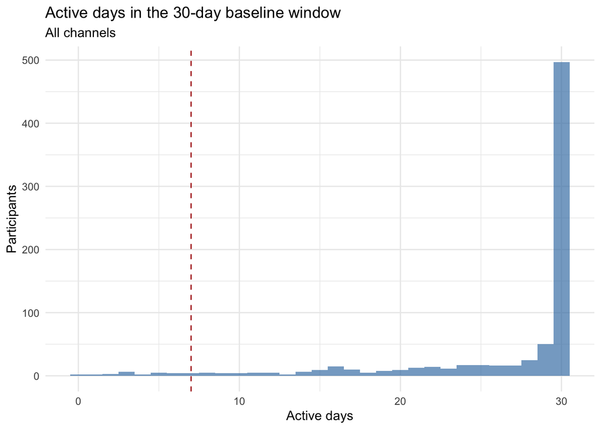

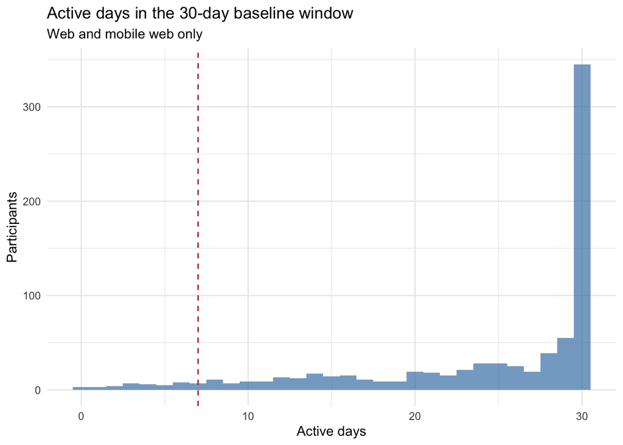

```r
plot_by_channel(
  habitual_long %>% distinct(pid, channel, n_active_days),
  function(d, lab)
    ggplot(d, aes(x = n_active_days)) +
      geom_histogram(binwidth = 1, fill = "steelblue", alpha = 0.7) +
      geom_vline(xintercept = MIN_ACTIVE_DAYS, linetype = "dashed", colour = "firebrick") +
      labs(title = "Active days in the 30-day baseline window", subtitle = lab,
           x = "Active days", y = "Participants") +
      theme_minimal(),
  "MAIN_plot_active_days.png", width = 7, height = 5)
```

## 7.2 Level density

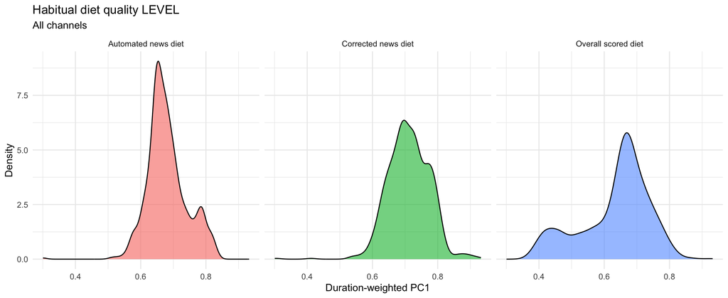

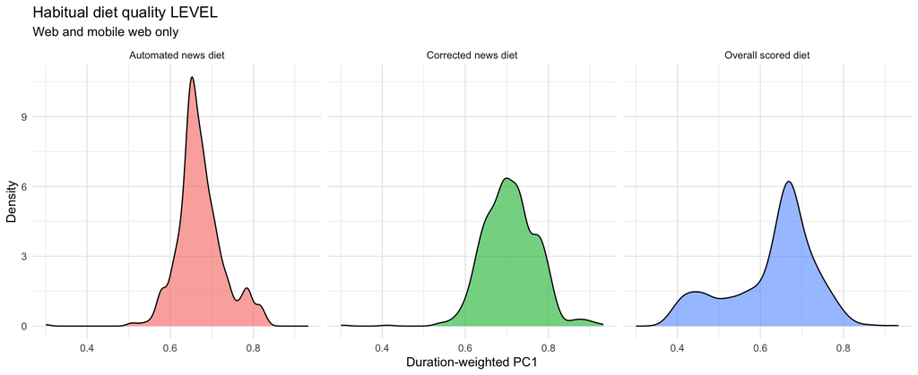

```r
plot_by_channel(
  habitual_long %>% filter(!is.na(duration_weighted_pc1)),
  function(d, lab)
    ggplot(d, aes(x = duration_weighted_pc1, fill = variant_label)) +
      geom_density(alpha = 0.6, show.legend = FALSE) + variant_facets() +
      labs(title = "Habitual diet quality LEVEL", subtitle = lab,
           x = "Duration-weighted PC1", y = "Density") +
      theme_minimal(),
  "MAIN_plot_level_density.png")
```

## 7.3 Diversity density

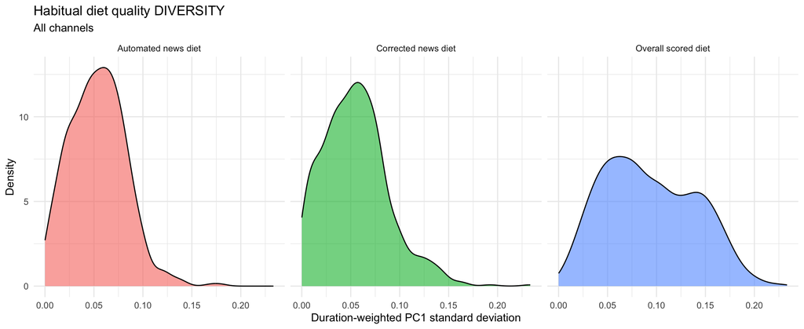

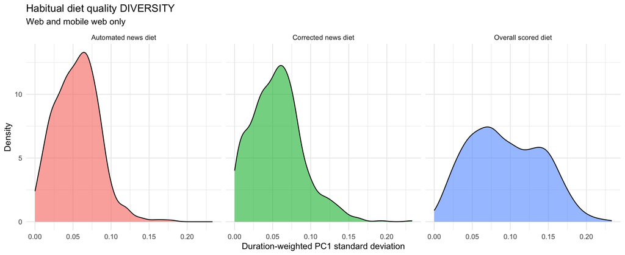

```r
plot_by_channel(
  habitual_long %>% filter(!is.na(duration_weighted_sd_pc1)),
  function(d, lab)
    ggplot(d, aes(x = duration_weighted_sd_pc1, fill = variant_label)) +
      geom_density(alpha = 0.6, show.legend = FALSE) + variant_facets() +
      labs(title = "Habitual diet quality DIVERSITY", subtitle = lab,
           x = "Duration-weighted PC1 standard deviation", y = "Density") +
      theme_minimal(),
  "MAIN_plot_diversity_density.png")
```

## 7.4 Level versus diversity

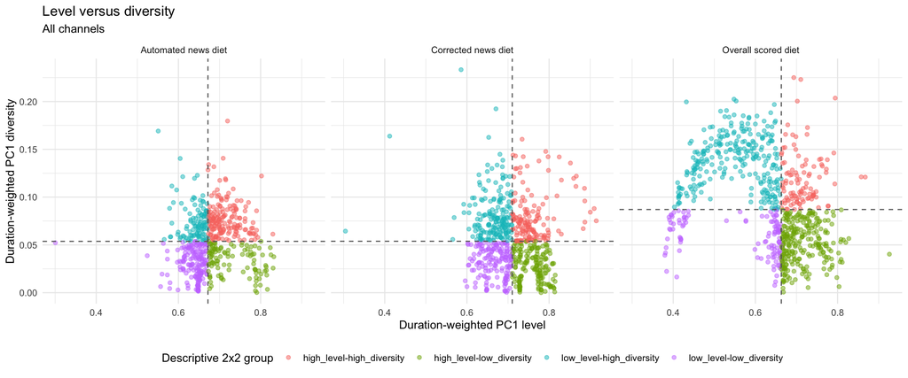

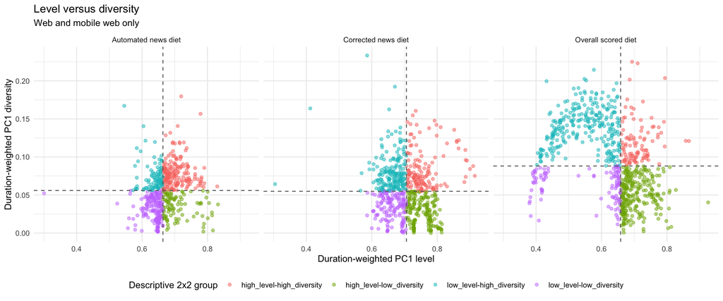

```r
plot_by_channel(
  habitual_long %>% filter(!is.na(duration_weighted_pc1), !is.na(duration_weighted_sd_pc1)),
  function(d, lab)
    ggplot(d, aes(x = duration_weighted_pc1, y = duration_weighted_sd_pc1,
                  colour = habitual_diet_diversity_group)) +
      geom_point(alpha = 0.5) +
      geom_vline(aes(xintercept = median_duration_weighted_pc1),
                 linetype = "dashed", colour = "grey40") +
      geom_hline(aes(yintercept = median_duration_weighted_sd_pc1),
                 linetype = "dashed", colour = "grey40") +
      variant_facets() +
      labs(title = "Level versus diversity", subtitle = lab,
           x = "Duration-weighted PC1 level", y = "Duration-weighted PC1 diversity",
           colour = "Descriptive 2x2 group") +
      theme_minimal() + theme(legend.position = "bottom"),
  "MAIN_plot_level_vs_diversity.png", width = 12, height = 5)
```

## 7.5 2x2 subgroup sizes

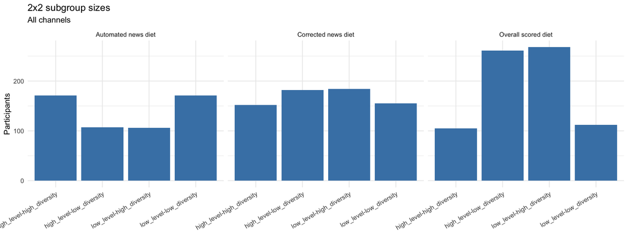

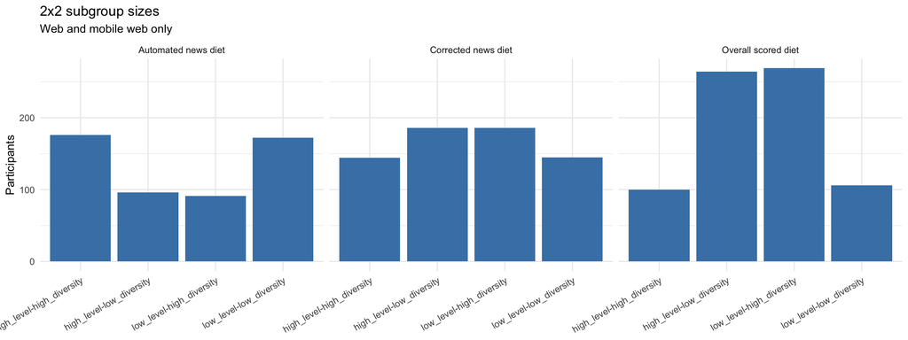

```r
plot_by_channel(
  habitual_long %>% filter(!is.na(habitual_diet_diversity_group)),
  function(d, lab)
    ggplot(d, aes(x = habitual_diet_diversity_group)) +
      geom_bar(fill = "steelblue") + variant_facets() +
      labs(title = "2x2 subgroup sizes", subtitle = lab, x = NULL, y = "Participants") +
      theme_minimal() + theme(axis.text.x = element_text(angle = 30, hjust = 1)),
  "MAIN_plot_2x2_group_sizes.png", width = 12, height = 4.5)
```

## 7.6 Coverage per definition

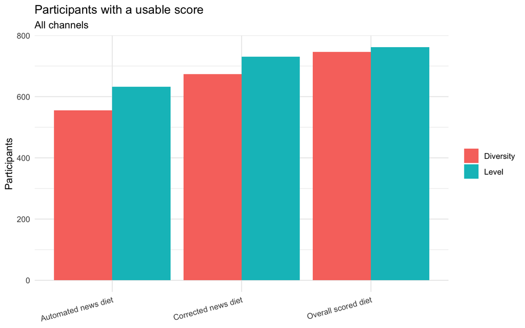

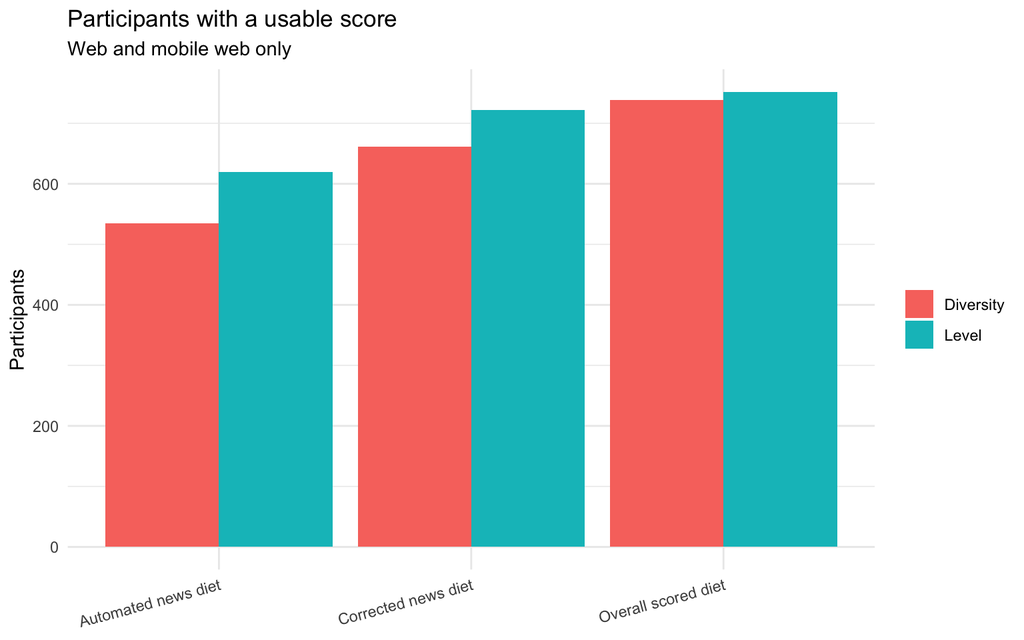

```r
plot_by_channel(
  measure_coverage %>%
    dplyr::select(channel, variant_label, level_available, diversity_available) %>%
    pivot_longer(c(level_available, diversity_available),
                 names_to = "measure", values_to = "n_participants") %>%
    mutate(measure = recode(measure, level_available = "Level",
                            diversity_available = "Diversity")),
  function(d, lab)
    ggplot(d, aes(x = variant_label, y = n_participants, fill = measure)) +
      geom_col(position = "dodge") +
      labs(title = "Participants with a usable score", subtitle = lab,
           x = NULL, y = "Participants", fill = NULL) +
      theme_minimal() + theme(axis.text.x = element_text(angle = 15, hjust = 1)),
  "MAIN_plot_coverage.png", width = 8, height = 5)
```

# 8 Part 7: Diagnostics

| Diagnostic | Question |
| --- | --- |
| A | Does the individual reference date matter versus a shared pre-Wave-1 date? |
| B | Does the 30-day window matter versus full history? |
| C | Does duration weighting matter versus an unweighted mean? |
| D | Is the level distribution skewed enough that median and mean diverge? |
| E | Do qualifying participants actually show repeated source use? |

## 8.1 Generic builder

Takes the same `flag_col` argument as the main construction step, plus a reference-date rule and a window rule, so A–C run once per combination x rule rather than being hard-coded to one variant.

```r
pid_reference_A <- pid_wave_search %>%
  group_by(pid) %>%
  summarise(reference_date = as.Date(min(search_start)) - 1, .groups = "drop")

pid_reference_B <- tibble(pid = unique(pid_wave_search$pid),
                          reference_date = WAVE1_START_FIXED - 1)

pid_reference_lookup <- list(individual = pid_reference_A, fixed_pre_wave1 = pid_reference_B)

window_start_rules <- list(
  `30day` = function(ref) ref - (BASELINE_WINDOW_DAYS - 1),
  full    = function(ref) rep(DATA_COLLECTION_START, length(ref))
)

build_variant_baseline <- function(flag_col, visits_df, pid_reference,
                                   window_rule, min_active_days) {
  windows <- pid_reference %>%
    mutate(window_start = window_rule(reference_date),
           window_days = as.numeric(reference_date - window_start) + 1)

  visits_window <- visits_df %>%
    inner_join(windows, by = "pid") %>%
    filter(used_date >= window_start, used_date <= reference_date)

  subset <- if (is.na(flag_col)) visits_window
            else visits_window[visits_window[[flag_col]] %in% TRUE, , drop = FALSE]

  activity <- subset %>%
    group_by(pid) %>%
    summarise(n_rows_with_pc1 = sum(!is.na(pc1)),
              n_distinct_pc1 = n_distinct(pc1[!is.na(pc1)]),
              duration_weighted_pc1 = weighted_mean_na(pc1, duration),
              duration_weighted_sd_pc1 = weighted_sd_na(pc1, duration),
              unweighted_pc1 = mean(pc1, na.rm = TRUE),
              .groups = "drop")

  # The threshold always counts ALL visits in the window, not the
  # variant-filtered subset, consistent with the main construction step:
  # "habitual" is defined by overall browsing activity.
  all_active <- visits_window %>%
    group_by(pid) %>% summarise(n_active_days = n_distinct(used_date), .groups = "drop")

  windows %>%
    dplyr::select(pid, window_days) %>%
    left_join(all_active, by = "pid") %>%
    left_join(activity, by = "pid") %>%
    mutate(
      across(c(n_active_days, n_rows_with_pc1, n_distinct_pc1), ~ coalesce(.x, 0L)),
      meets_activity_threshold = n_active_days >= min_active_days,
      across(c(duration_weighted_pc1, duration_weighted_sd_pc1, unweighted_pc1),
             ~ if_else(meets_activity_threshold, .x, NA_real_))
    )
}
```

```r
diag_rules <- tribble(
  ~baseline_version,  ~window_type,  ~min_active_days,
  "individual",       "30day",       MIN_ACTIVE_DAYS,
  "individual",       "full",        MIN_ACTIVE_DAYS_FULL,
  "fixed_pre_wave1",  "30day",       MIN_ACTIVE_DAYS,
  "fixed_pre_wave1",  "full",        MIN_ACTIVE_DAYS_FULL
)

all_habitual <- cross_join(analysis_grid, diag_rules) %>%
  mutate(result = pmap(list(flag_col, channel, baseline_version, window_type, min_active_days),
    function(fc, ch, bv, wt, mad)
      build_variant_baseline(fc, visits_by_channel[[ch]], pid_reference_lookup[[bv]],
                             window_start_rules[[wt]], mad))) %>%
  dplyr::select(channel, channel_label, variant, variant_label,
                baseline_version, window_type, result) %>%
  unnest(result) %>%
  mutate(channel = factor(channel, levels = channel_levels),
         variant = factor(variant, levels = variant_levels))

write_csv(all_habitual, file.path(diagnostics_dir, "diagnostic_all_variants_versions.csv"))
cat("Diagnostic rows (participants x 6 combinations x 4 rules):", nrow(all_habitual), "\n")
```

```
## Diagnostic rows (participants x 6 combinations x 4 rules): 18984
```

## 8.2 A: reference date

The individual date is preferred because it is the only rule that guarantees each participant’s baseline precedes their own first search task. A high correlation shows that the choice does not materially change the measure.

```r
all_habitual %>%
  filter(window_type == "30day") %>%
  dplyr::select(pid, channel, variant, baseline_version, duration_weighted_pc1) %>%
  pivot_wider(names_from = baseline_version, values_from = duration_weighted_pc1) %>%
  group_by(channel, variant) %>%
  summarise(n = sum(complete.cases(individual, fixed_pre_wave1)),
            r = round(cor(individual, fixed_pre_wave1, use = "complete.obs"), 3),
            .groups = "drop")
```

```
## # A tibble: 6 × 4
##   channel      variant            n     r
##   <fct>        <fct>          <int> <dbl>
## 1 with_apps    overall          759 0.99
## 2 with_apps    news             624 0.95
## 3 with_apps    news_corrected   721 0.96
## 4 without_apps overall          747 0.989
## 5 without_apps news             606 0.928
## 6 without_apps news_corrected   711 0.958
```

## 8.3 B: window length

```r
agreement_30day_full <- all_habitual %>%
  filter(baseline_version == "individual", window_type == "30day") %>%
  dplyr::select(pid, channel, channel_label, variant, variant_label,
                pc1_30day = duration_weighted_pc1) %>%
  inner_join(all_habitual %>%
               filter(baseline_version == "individual", window_type == "full") %>%
               dplyr::select(pid, channel, variant, pc1_full = duration_weighted_pc1),
             by = c("pid", "channel", "variant")) %>%
  filter(!is.na(pc1_30day), !is.na(pc1_full))

agreement_30day_full %>%
  group_by(channel, variant) %>%
  summarise(n = n(), r = round(cor(pc1_30day, pc1_full), 3), .groups = "drop")
```

```
## # A tibble: 6 × 4
##   channel      variant            n     r
##   <fct>        <fct>          <int> <dbl>
## 1 with_apps    overall          757 0.95
## 2 with_apps    news             631 0.881
## 3 with_apps    news_corrected   727 0.898
## 4 without_apps overall          743 0.947
## 5 without_apps news             616 0.836
## 6 without_apps news_corrected   717 0.894
```

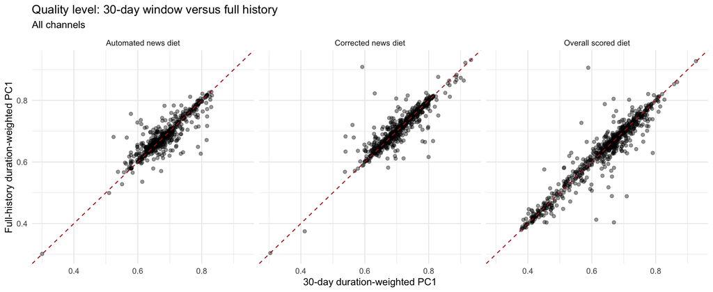

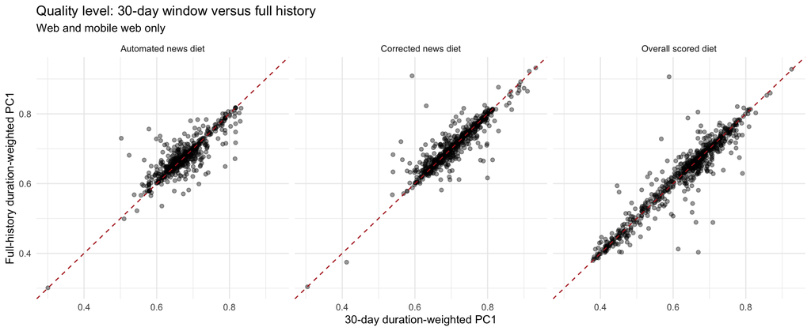

```r
plot_by_channel(
  agreement_30day_full,
  function(d, lab)
    ggplot(d, aes(x = pc1_30day, y = pc1_full)) +
      geom_point(alpha = 0.4) +
      geom_abline(slope = 1, intercept = 0, linetype = "dashed", colour = "firebrick") +
      variant_facets() +
      labs(title = "Quality level: 30-day window versus full history", subtitle = lab,
           x = "30-day duration-weighted PC1", y = "Full-history duration-weighted PC1") +
      theme_minimal(),
  "diagB_window_agreement.png")
```

## 8.4 C: duration weighting

```r
all_habitual %>%
  filter(baseline_version == "individual", window_type == "30day") %>%
  group_by(channel, variant) %>%
  group_modify(function(df, ...) {
    m <- df %>%
      dplyr::select(unweighted_pc1, duration_weighted_pc1, duration_weighted_sd_pc1) %>%
      filter(complete.cases(.))
    if (nrow(m) < 3) return(tibble(note = "insufficient complete cases"))
    as_tibble(round(cor(m), 3), rownames = "metric")
  }) %>%
  print(n = Inf)
```

```
## # A tibble: 18 × 6
## # Groups:   channel, variant [6]
##    channel      variant        metric       unweighted_pc1 duration_weighted_pc1
##    <fct>        <fct>          <chr>                 <dbl>                 <dbl>
##  1 with_apps    overall        unweighted_…          1                     0.859
##  2 with_apps    overall        duration_we…          0.859                 1
##  3 with_apps    overall        duration_we…         -0.258                -0.38
##  4 with_apps    news           unweighted_…          1                     0.918
##  5 with_apps    news           duration_we…          0.918                 1
##  6 with_apps    news           duration_we…          0.1                   0.077
##  7 with_apps    news_corrected unweighted_…          1                     0.875
##  8 with_apps    news_corrected duration_we…          0.875                 1
##  9 with_apps    news_corrected duration_we…         -0.165                -0.106
## 10 without_apps overall        unweighted_…          1                     0.853
## 11 without_apps overall        duration_we…          0.853                 1
## 12 without_apps overall        duration_we…         -0.25                 -0.37
## 13 without_apps news           unweighted_…          1                     0.89
## 14 without_apps news           duration_we…          0.89                  1
## 15 without_apps news           duration_we…          0.193                 0.167
## 16 without_apps news_corrected unweighted_…          1                     0.873
## 17 without_apps news_corrected duration_we…          0.873                 1
## 18 without_apps news_corrected duration_we…         -0.163                -0.09
## # ℹ 1 more variable: duration_weighted_sd_pc1 <dbl>
```

## 8.5 D: median versus mean

```r
habitual_long %>%
  group_by(channel, variant) %>%
  summarise(across(c(duration_weighted_pc1, duration_weighted_sd_pc1),
                   list(median = ~ round(median(.x, na.rm = TRUE), 4),
                        mean   = ~ round(mean(.x, na.rm = TRUE), 4))),
            .groups = "drop")
```

```
## # A tibble: 6 × 6
##   channel      variant        duration_weighted_pc1_med…¹ duration_weighted_pc…²
##   <fct>        <fct>                                <dbl>                  <dbl>
## 1 with_apps    overall                              0.663                  0.634
## 2 with_apps    news                                 0.672                  0.680
## 3 with_apps    news_corrected                       0.710                  0.712
## 4 without_apps overall                              0.658                  0.629
## 5 without_apps news                                 0.664                  0.672
## 6 without_apps news_corrected                       0.706                  0.708
## # ℹ abbreviated names: ¹duration_weighted_pc1_median,
## #   ²duration_weighted_pc1_mean
## # ℹ 2 more variables: duration_weighted_sd_pc1_median <dbl>,
## #   duration_weighted_sd_pc1_mean <dbl>
```

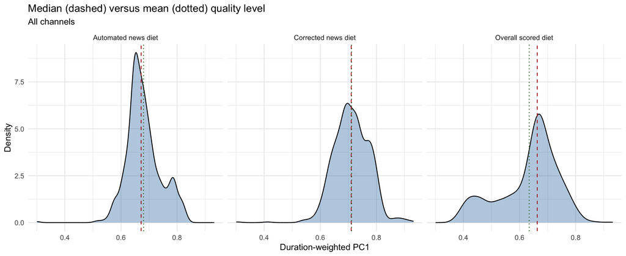

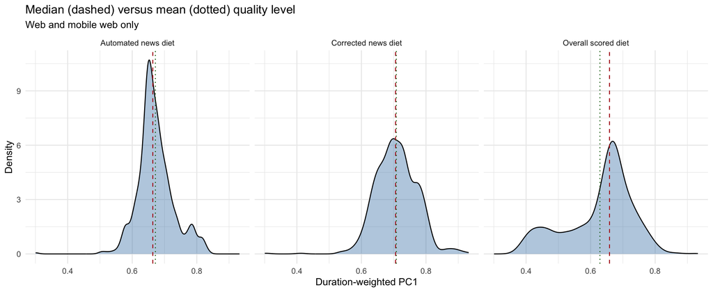

```r
plot_by_channel(
  habitual_long %>% filter(!is.na(duration_weighted_pc1)) %>%
    group_by(channel, variant_label) %>%
    mutate(med = median(duration_weighted_pc1), avg = mean(duration_weighted_pc1)) %>%
    ungroup(),
  function(d, lab)
    ggplot(d, aes(x = duration_weighted_pc1)) +
      geom_density(fill = "steelblue", alpha = 0.4) +
      geom_vline(aes(xintercept = med), linetype = "dashed", colour = "firebrick") +
      geom_vline(aes(xintercept = avg), linetype = "dotted", colour = "darkgreen") +
      variant_facets() +
      labs(title = "Median (dashed) versus mean (dotted) quality level", subtitle = lab,
           x = "Duration-weighted PC1", y = "Density") +
      theme_minimal(),
  "diagD_median_vs_mean.png")
```

## 8.6 E: repeated-source behaviour

Computed within each combination’s qualifying visits, so a repeat source for the news variant means a repeatedly visited news source, not a repeatedly visited domain in general.

```r
compute_repeat_summary <- function(flag_col, visits_df) {
  if (!is.na(flag_col)) visits_df <- visits_df[visits_df[[flag_col]] %in% TRUE, , drop = FALSE]

  visits_df %>%
    filter(!is.na(content_id)) %>%
    count(pid, content_id, name = "n_visits_this_source") %>%
    mutate(is_repeat_source = n_visits_this_source > 1) %>%
    group_by(pid) %>%
    summarise(n_distinct_sources = n(),
              n_repeat_sources = sum(is_repeat_source),
              share_repeat_visits = sum(n_visits_this_source[is_repeat_source]) /
                                    sum(n_visits_this_source),
              has_any_repeat_source = any(is_repeat_source),
              .groups = "drop")
}

habitual_with_repeats <- analysis_grid %>%
  mutate(repeats = map2(flag_col, channel,
                        ~ compute_repeat_summary(.x, visits_baseline[[.y]]))) %>%
  dplyr::select(channel, variant, repeats) %>%
  unnest(repeats) %>%
  right_join(habitual_long %>%
               dplyr::select(pid, channel, channel_label, variant, variant_label,
                             meets_activity_threshold),
             by = c("pid", "channel", "variant")) %>%
  mutate(across(c(n_distinct_sources, n_repeat_sources), ~ coalesce(.x, 0L)),
         share_repeat_visits = coalesce(share_repeat_visits, 0),
         has_any_repeat_source = coalesce(has_any_repeat_source, FALSE))

write_csv(habitual_with_repeats,
          file.path(diagnostics_dir, "diagnostic_repeat_visits_all_variants.csv"))

qualifying <- habitual_with_repeats %>% filter(meets_activity_threshold)

qualifying %>%
  group_by(channel, variant) %>%
  summarise(n_qualifying = n(),
            n_with_repeat_source = sum(has_any_repeat_source),
            median_share_repeat = round(median(share_repeat_visits, na.rm = TRUE), 3),
            .groups = "drop")
```

```
## # A tibble: 6 × 5
##   channel      variant     n_qualifying n_with_repeat_source median_share_repeat
##   <chr>        <chr>              <int>                <int>               <dbl>
## 1 with_apps    news                 767                  592               0.8
## 2 with_apps    news_corre…          767                  693               0.917
## 3 with_apps    overall              767                  767               0.944
## 4 without_apps news                 755                  549               0.667
## 5 without_apps news_corre…          755                  667               0.882
## 6 without_apps overall              755                  755               0.819
```

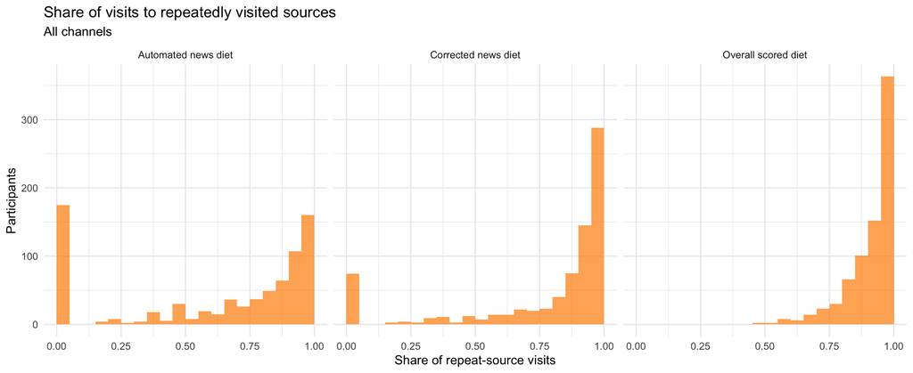

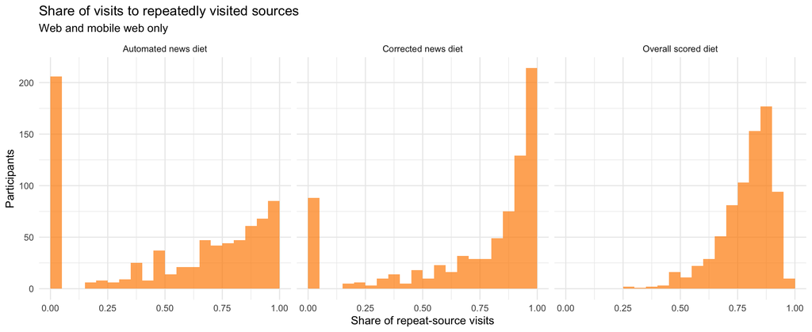

```r
plot_by_channel(
  qualifying,
  function(d, lab)
    ggplot(d, aes(x = share_repeat_visits)) +
      geom_histogram(binwidth = 0.05, fill = "darkorange", alpha = 0.7, boundary = 0) +
      variant_facets() +
      labs(title = "Share of visits to repeatedly visited sources", subtitle = lab,
           x = "Share of repeat-source visits", y = "Participants") +
      theme_minimal(),
  "diagE_repeat_source_share.png")
```

## 8.7 F: log-duration weighting versus raw duration weighting

Session duration in tracking data is heavily right-skewed and approximately log-normally distributed (Meiss et al., 2009; Brinberg et al., 2022), so a few very long sessions – idle tabs, autoplay, background windows – can dominate a linearly duration-weighted average. This checks whether that matters here: level is recomputed with `log1p(duration)` as the weight and correlated against the raw-weighted version, per variant. `log1p()` avoids the `log(0)` problem without an arbitrary epsilon.

```r
weighted_mean_log_na <- function(x, w) {
  keep <- !is.na(x) & !is.na(w) & w > 0
  if (!any(keep)) return(NA_real_)
  w_log <- log1p(w[keep])
  sum(x[keep] * w_log) / sum(w_log)
}

# Takes the channel name and indexes straight into visits_baseline, which is
# already channel-split and window-filtered -- same input as the main build.
build_variant_logw <- function(channel, flag_col) {
  v <- visits_baseline[[channel]]
  v <- if (is.na(flag_col)) v else v[v[[flag_col]] %in% TRUE, , drop = FALSE]

  v %>%
    group_by(pid) %>%
    summarise(log_duration_weighted_pc1 = weighted_mean_log_na(pc1, duration),
              .groups = "drop")
}

habitual_logw <- analysis_grid %>%
  mutate(activity = map2(channel, flag_col, build_variant_logw)) %>%
  dplyr::select(channel, variant, activity) %>%
  unnest(activity)

logw_compare <- habitual_long %>%
  dplyr::select(pid, channel, variant, variant_label,
                meets_activity_threshold, duration_weighted_pc1) %>%
  left_join(habitual_logw, by = c("pid", "channel", "variant")) %>%
  mutate(log_duration_weighted_pc1 =
           if_else(meets_activity_threshold, log_duration_weighted_pc1, NA_real_))

# Guard against the fan-out that produced n > 791 in the first run.
stopifnot(nrow(logw_compare) == nrow(habitual_long))

cat("Raw vs. log-duration-weighted level, per channel and variant:\n")
```

```
## Raw vs. log-duration-weighted level, per channel and variant:
```

```r
logw_compare %>%
  filter(!is.na(duration_weighted_pc1), !is.na(log_duration_weighted_pc1)) %>%
  group_by(channel, variant, variant_label) %>%
  summarise(n = n(),
            r = round(cor(duration_weighted_pc1, log_duration_weighted_pc1), 3),
            mean_abs_diff = round(mean(abs(duration_weighted_pc1 - log_duration_weighted_pc1)), 4),
            .groups = "drop") %>%
  print()
```

```
## # A tibble: 6 × 6
##   channel      variant        variant_label           n     r mean_abs_diff
##   <chr>        <chr>          <chr>               <int> <dbl>         <dbl>
## 1 with_apps    news           Automated news diet   632 0.966        0.01
## 2 with_apps    news_corrected Corrected news diet   730 0.933        0.0126
## 3 with_apps    overall        Overall scored diet   762 0.923        0.0326
## 4 without_apps news           Automated news diet   620 0.959        0.0101
## 5 without_apps news_corrected Corrected news diet   722 0.934        0.0127
## 6 without_apps overall        Overall scored diet   752 0.921        0.0331
```

```r
write_csv(logw_compare, file.path(diagnostics_dir, "diagF_log_weighting.csv"))
```

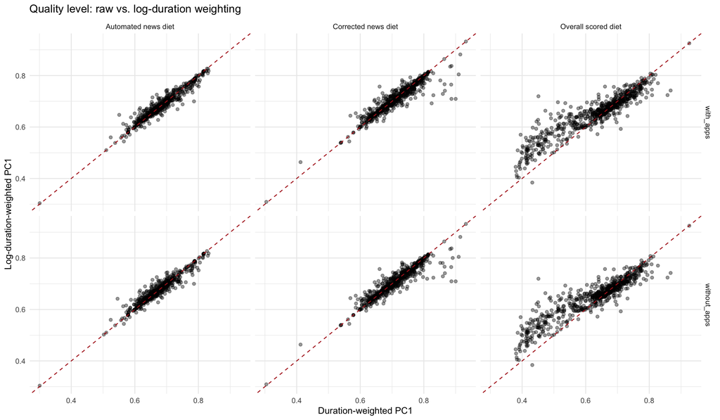

```r
p_logw <- logw_compare %>%
  filter(!is.na(duration_weighted_pc1), !is.na(log_duration_weighted_pc1)) %>%
  ggplot(aes(x = duration_weighted_pc1, y = log_duration_weighted_pc1)) +
  geom_point(alpha = 0.4) +
  geom_abline(slope = 1, intercept = 0, linetype = "dashed", color = "firebrick") +
  facet_grid(channel ~ variant_label) +
  labs(title = "Quality level: raw vs. log-duration weighting",
       x = "Duration-weighted PC1", y = "Log-duration-weighted PC1") +
  theme_minimal()

print(p_logw)
```

```r
ggsave(file.path(diagnostics_dir, "diagF_logweight_faceted.png"), p_logw, width = 12, height = 7)
```

**Reading rule.** `r` above roughly .95 means the weighting choice does not materially reorder participants; keep raw duration-weighting for interpretability and note the check in one sentence. Markedly lower `r` means a minority of extreme sessions is driving that variant’s score, and the log-weighted version should be carried forward as a reported robustness check.

```r
split_agreement <- logw_compare %>%
  filter(!is.na(duration_weighted_pc1), !is.na(log_duration_weighted_pc1)) %>%
  group_by(channel, variant, variant_label) %>%
  mutate(
    split_raw = if_else(duration_weighted_pc1     <= median(duration_weighted_pc1),     "low", "high"),
    split_log = if_else(log_duration_weighted_pc1 <= median(log_duration_weighted_pc1), "low", "high")
  ) %>%
  summarise(
    n            = n(),
    n_agree      = sum(split_raw == split_log),
    pct_agree    = round(100 * mean(split_raw == split_log), 1),
    n_switch     = sum(split_raw != split_log),
    .groups = "drop"
  )

cat("Median-split agreement, raw vs. log weighting:\n")
```

```
## Median-split agreement, raw vs. log weighting:
```

```r
print(split_agreement)
```

```
## # A tibble: 6 × 7
##   channel      variant        variant_label         n n_agree pct_agree n_switch
##   <chr>        <chr>          <chr>             <int>   <int>     <dbl>    <int>
## 1 with_apps    news           Automated news d…   632     590      93.4       42
## 2 with_apps    news_corrected Corrected news d…   730     668      91.5       62
## 3 with_apps    overall        Overall scored d…   762     686      90         76
## 4 without_apps news           Automated news d…   620     562      90.6       58
## 5 without_apps news_corrected Corrected news d…   722     670      92.8       52
## 6 without_apps overall        Overall scored d…   752     666      88.6       86
```

```r
write_csv(split_agreement, file.path(diagnostics_dir, "diagF_split_agreement.csv"))
```

```r
# Exported so 03b can re-run the moderation with the alternative weighting.
logw_split <- logw_compare %>%
  filter(!is.na(log_duration_weighted_pc1)) %>%
  group_by(channel, variant) %>%
  mutate(habitual_diet_logw = if_else(
    log_duration_weighted_pc1 <= median(log_duration_weighted_pc1), "low", "high")) %>%
  ungroup() %>%
  dplyr::select(pid, channel, variant,
                log_duration_weighted_pc1, habitual_diet_logw)

write_csv(logw_split, file.path(output_dir, "habitual_logweighted_split.csv"))
cat("Exported log-weighted level and split for", n_distinct(logw_split$pid), "participants\n")
```

```
## Exported log-weighted level and split for 762 participants
```

```r
dur_check_hab <- bind_rows(visits_baseline) %>%
  as_tibble() %>%
  filter(!is.na(pc1))

cat("Duration distribution of scored baseline visits (seconds):\n")
```

```
## Duration distribution of scored baseline visits (seconds):
```

```r
dur_check_hab %>%
  summarise(n = n(),
            min = min(duration, na.rm = TRUE),
            p25 = quantile(duration, .25, na.rm = TRUE),
            median = median(duration, na.rm = TRUE),
            p75 = quantile(duration, .75, na.rm = TRUE),
            p95 = quantile(duration, .95, na.rm = TRUE),
            p99 = quantile(duration, .99, na.rm = TRUE),
            max = max(duration, na.rm = TRUE),
            n_zero = sum(duration == 0, na.rm = TRUE)) %>%
  print(width = Inf)
```

```
## # A tibble: 1 × 9
##        n   min   p25 median   p75   p95   p99   max n_zero
##    <int> <dbl> <dbl>  <dbl> <dbl> <dbl> <dbl> <dbl>  <int>
## 1 306571     1    18     73   248  1281 3921. 69054      0
```

```r
cat("\nVisits above plausible reading thresholds:\n")
```

```
##
## Visits above plausible reading thresholds:
```

```r
dur_check_hab %>%
  summarise(n = n(),
            over_30min = sum(duration > 1800, na.rm = TRUE),
            over_1h    = sum(duration > 3600, na.rm = TRUE),
            over_3h    = sum(duration > 10800, na.rm = TRUE),
            over_8h    = sum(duration > 28800, na.rm = TRUE),
            pct_over_30min = round(100 * mean(duration > 1800, na.rm = TRUE), 2),
            share_of_total_time_over_30min =
              round(100 * sum(duration[duration > 1800], na.rm = TRUE) /
                      sum(duration, na.rm = TRUE), 1)) %>%
  print(width = Inf)
```

```
## # A tibble: 1 × 7
##        n over_30min over_1h over_3h over_8h pct_over_30min
##    <int>      <int>   <int>   <int>   <int>          <dbl>
## 1 306571       9926    3572     484      48           3.24
##   share_of_total_time_over_30min
##                            <dbl>
## 1                           42.6
```

```r
# Same, split by diet definition -- the overall diet was the most
# weighting-sensitive variant in Diagnostic F.
cat("\nBy diet definition:\n")
```

```
##
## By diet definition:
```

```r
bind_rows(
  dur_check_hab %>% mutate(variant = "overall"),
  dur_check_hab %>% filter(is_news %in% TRUE) %>% mutate(variant = "news"),
  dur_check_hab %>% filter(is_news_corrected %in% TRUE) %>% mutate(variant = "news_corrected")
) %>%
  group_by(variant) %>%
  summarise(n = n(),
            median = median(duration, na.rm = TRUE),
            p99 = quantile(duration, .99, na.rm = TRUE),
            max = max(duration, na.rm = TRUE),
            pct_over_30min = round(100 * mean(duration > 1800, na.rm = TRUE), 2),
            share_time_over_30min =
              round(100 * sum(duration[duration > 1800], na.rm = TRUE) /
                      sum(duration, na.rm = TRUE), 1),
            .groups = "drop") %>%
  print(width = Inf)
```

```
## # A tibble: 3 × 7
##   variant             n median   p99   max pct_over_30min share_time_over_30min
##   <chr>           <int>  <dbl> <dbl> <dbl>          <dbl>                 <dbl>
## 1 news            68075     64 1431  15437           0.61                  12.8
## 2 news_corrected 153978     78 2269. 69054           1.51                  25.4
## 3 overall        306571     73 3921. 69054           3.24                  42.6
```

## 8.8 G: Capping

```r
# Capping addresses a measurement artefact: sessions of several hours are
# parked tabs, not reading time. Unlike the log transformation, capping
# leaves the 97% of unremarkable visits untouched and keeps the measure
# interpretable as quality per unit of browsing time.
caps <- c("cap_30min" = 1800L, "cap_1h" = 3600L, "cap_3h" = 10800L)

build_variant_capped <- function(channel, flag_col, cap_seconds) {
  v <- visits_baseline[[channel]]
  v <- if (is.na(flag_col)) v else v[v[[flag_col]] %in% TRUE, , drop = FALSE]

  v %>%
    mutate(duration_capped = pmin(duration, cap_seconds)) %>%
    group_by(pid) %>%
    summarise(level_capped = weighted_mean_na(pc1, duration_capped),
              .groups = "drop")
}

capped_levels <- purrr::imap_dfr(caps, function(cap_seconds, cap_label) {
  analysis_grid %>%
    mutate(activity = map2(channel, flag_col, build_variant_capped,
                           cap_seconds = cap_seconds)) %>%
    dplyr::select(channel, variant, activity) %>%
    unnest(activity) %>%
    mutate(cap = cap_label)
})

cap_compare <- habitual_long %>%
  dplyr::select(pid, channel, variant, variant_label,
                meets_activity_threshold, duration_weighted_pc1) %>%
  left_join(capped_levels, by = c("pid", "channel", "variant"),
            relationship = "one-to-many") %>%
  mutate(level_capped = if_else(meets_activity_threshold, level_capped, NA_real_)) %>%
  filter(!is.na(duration_weighted_pc1), !is.na(level_capped))
```

```r
# How much weight is actually removed at each threshold?
cat("Share of weighted time removed by capping, by variant:\n")
```

```
## Share of weighted time removed by capping, by variant:
```

```r
bind_rows(
  dur_check_hab %>% mutate(variant = "overall"),
  dur_check_hab %>% filter(is_news %in% TRUE) %>% mutate(variant = "news"),
  dur_check_hab %>% filter(is_news_corrected %in% TRUE) %>% mutate(variant = "news_corrected")
) %>%
  group_by(variant) %>%
  summarise(
    n_visits = n(),
    pct_visits_capped_30min = round(100 * mean(duration > 1800), 2),
    pct_visits_capped_1h    = round(100 * mean(duration > 3600), 2),
    pct_visits_capped_3h    = round(100 * mean(duration > 10800), 2),
    pct_time_removed_30min  = round(100 * (1 - sum(pmin(duration, 1800))  / sum(duration)), 1),
    pct_time_removed_1h     = round(100 * (1 - sum(pmin(duration, 3600))  / sum(duration)), 1),
    pct_time_removed_3h     = round(100 * (1 - sum(pmin(duration, 10800)) / sum(duration)), 1),
    .groups = "drop"
  ) %>%
  as.data.frame() %>% print()
```

```
##          variant n_visits pct_visits_capped_30min pct_visits_capped_1h
## 1           news    68075                    0.61                 0.16
## 2 news_corrected   153978                    1.51                 0.47
## 3        overall   306571                    3.24                 1.17
##   pct_visits_capped_3h pct_time_removed_30min pct_time_removed_1h
## 1                 0.01                    5.9                 2.4
## 2                 0.06                   13.7                 7.5
## 3                 0.16                   24.3                13.3
##   pct_time_removed_3h
## 1                 0.1
## 2                 2.1
## 3                 3.6
```

```r
cat("\nCapped vs. uncapped level, by cap and variant (with_apps only):\n")
```

```
##
## Capped vs. uncapped level, by cap and variant (with_apps only):
```

```r
cap_compare %>%
  filter(channel == "with_apps") %>%
  group_by(cap, variant, variant_label) %>%
  summarise(n = n(),
            r = round(cor(duration_weighted_pc1, level_capped), 3),
            mean_diff = round(mean(level_capped - duration_weighted_pc1), 4),
            mean_abs_diff = round(mean(abs(level_capped - duration_weighted_pc1)), 4),
            .groups = "drop") %>%
  arrange(variant, cap) %>%
  as.data.frame() %>% print()
```

```
##         cap        variant       variant_label   n     r mean_diff
## 1    cap_1h           news Automated news diet 632 1.000   -0.0001
## 2 cap_30min           news Automated news diet 632 0.999   -0.0002
## 3    cap_3h           news Automated news diet 632 1.000    0.0000
## 4    cap_1h news_corrected Corrected news diet 730 0.997   -0.0003
## 5 cap_30min news_corrected Corrected news diet 730 0.993   -0.0007
## 6    cap_3h news_corrected Corrected news diet 730 0.999   -0.0001
## 7    cap_1h        overall Overall scored diet 762 0.997    0.0004
## 8 cap_30min        overall Overall scored diet 762 0.992    0.0026
## 9    cap_3h        overall Overall scored diet 762 0.999   -0.0004
##   mean_abs_diff
## 1        0.0001
## 2        0.0003
## 3        0.0000
## 4        0.0005
## 5        0.0011
## 6        0.0001
## 7        0.0020
## 8        0.0051
## 9        0.0005
```

```r
# The moderation analysis uses the median split, so this is the comparison
# that decides whether the choice of threshold matters substantively.
cat("\nMedian-split agreement, capped vs. uncapped:\n")
```

```
##
## Median-split agreement, capped vs. uncapped:
```

```r
cap_compare %>%
  group_by(channel, cap, variant, variant_label) %>%
  mutate(split_uncapped = if_else(duration_weighted_pc1 <= median(duration_weighted_pc1), "low", "high"),
         split_capped   = if_else(level_capped          <= median(level_capped),          "low", "high")) %>%
  summarise(n = n(),
            pct_agree = round(100 * mean(split_uncapped == split_capped), 1),
            n_switch  = sum(split_uncapped != split_capped),
            .groups = "drop") %>%
  arrange(channel, variant, cap) %>%
  as.data.frame() %>% print()
```

```
##         channel       cap        variant       variant_label   n pct_agree
## 1     with_apps    cap_1h           news Automated news diet 632      99.7
## 2     with_apps cap_30min           news Automated news diet 632      99.7
## 3     with_apps    cap_3h           news Automated news diet 632     100.0
## 4     with_apps    cap_1h news_corrected Corrected news diet 730      99.7
## 5     with_apps cap_30min news_corrected Corrected news diet 730      99.5
## 6     with_apps    cap_3h news_corrected Corrected news diet 730     100.0
## 7     with_apps    cap_1h        overall Overall scored diet 762      99.2
## 8     with_apps cap_30min        overall Overall scored diet 762      98.2
## 9     with_apps    cap_3h        overall Overall scored diet 762      99.7
## 10 without_apps    cap_1h           news Automated news diet 620     100.0
## 11 without_apps cap_30min           news Automated news diet 620      99.7
## 12 without_apps    cap_3h           news Automated news diet 620     100.0
## 13 without_apps    cap_1h news_corrected Corrected news diet 722     100.0
## 14 without_apps cap_30min news_corrected Corrected news diet 722      99.4
```

[output cut: 23 more lines]

```r
# And the comparison that decides whether the threshold itself is an
# analytic fork: do the three caps agree with each other?
cat("\nAgreement between cap thresholds (with_apps):\n")
```

```
##
## Agreement between cap thresholds (with_apps):
```

```r
cap_compare %>%
  filter(channel == "with_apps") %>%
  dplyr::select(pid, variant, variant_label, cap, level_capped) %>%
  pivot_wider(names_from = cap, values_from = level_capped) %>%
  group_by(variant, variant_label) %>%
  summarise(n = n(),
            r_30min_vs_1h = round(cor(cap_30min, cap_1h), 4),
            r_1h_vs_3h    = round(cor(cap_1h, cap_3h), 4),
            r_30min_vs_3h = round(cor(cap_30min, cap_3h), 4),
            .groups = "drop") %>%
  as.data.frame() %>% print()
```

```
##          variant       variant_label   n r_30min_vs_1h r_1h_vs_3h r_30min_vs_3h
## 1           news Automated news diet 632        0.9998     0.9997        0.9991
## 2 news_corrected Corrected news diet 730        0.9988     0.9990        0.9964
## 3        overall Overall scored diet 762        0.9978     0.9989        0.9946
```

```r
write_csv(cap_compare, file.path(diagnostics_dir, "diagG_capping_comparison.csv"))
```

# 9 Part 8: Which Definition Carries the Most Information

“Most information” is not one number. It trades off how many participants get a usable score, how much that score varies across participants, how stable it is against arbitrary design choices, and — once an outcome exists — how strongly it relates to that outcome. The table assembles the design-stage criteria.

```r
variant_comparison <- habitual_long %>%
  group_by(channel, channel_label, variant, variant_label) %>%
  summarise(
    n_participants          = n(),
    n_meets_activity        = sum(meets_activity_threshold),
    pct_level_available     = round(100 * sum(!is.na(duration_weighted_pc1)) / n(), 1),
    pct_diversity_available = round(100 * sum(!is.na(duration_weighted_sd_pc1)) / n(), 1),
    sd_level                = round(sd(duration_weighted_pc1, na.rm = TRUE), 4),
    sd_diversity            = round(sd(duration_weighted_sd_pc1, na.rm = TRUE), 4),
    median_n_rows_with_pc1  = median(n_rows_with_pc1),
    .groups = "drop"
  ) %>%
  left_join(agreement_30day_full %>%
              group_by(channel, variant) %>%
              summarise(stability_30day_vs_full_r = round(cor(pc1_30day, pc1_full), 3),
                        .groups = "drop"),
            by = c("channel", "variant"))

variant_comparison
```

```
## # A tibble: 6 × 12
##   channel    channel_label variant variant_label n_participants n_meets_activity
##   <fct>      <chr>         <fct>   <chr>                  <int>            <int>
## 1 with_apps  All channels  overall Overall scor…            791              767
## 2 with_apps  All channels  news    Automated ne…            791              767
## 3 with_apps  All channels  news_c… Corrected ne…            791              767
## 4 without_a… Web and mobi… overall Overall scor…            791              755
## 5 without_a… Web and mobi… news    Automated ne…            791              755
## 6 without_a… Web and mobi… news_c… Corrected ne…            791              755
## # ℹ 6 more variables: pct_level_available <dbl>, pct_diversity_available <dbl>,
## #   sd_level <dbl>, sd_diversity <dbl>, median_n_rows_with_pc1 <int>,
## #   stability_30day_vs_full_r <dbl>
```

```r
write_csv(variant_comparison, file.path(channel_dirs[["with_apps"]],
                                        "habitual_media_diet_variant_comparison.csv"))
```

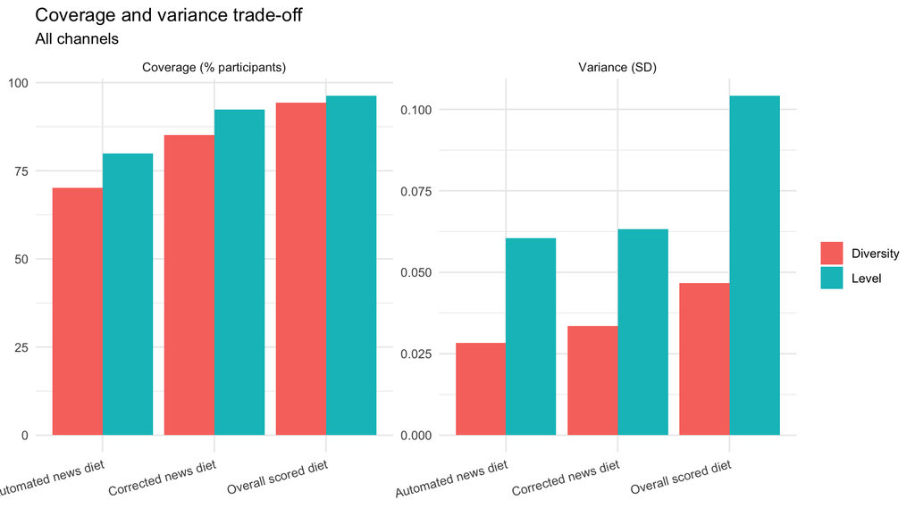

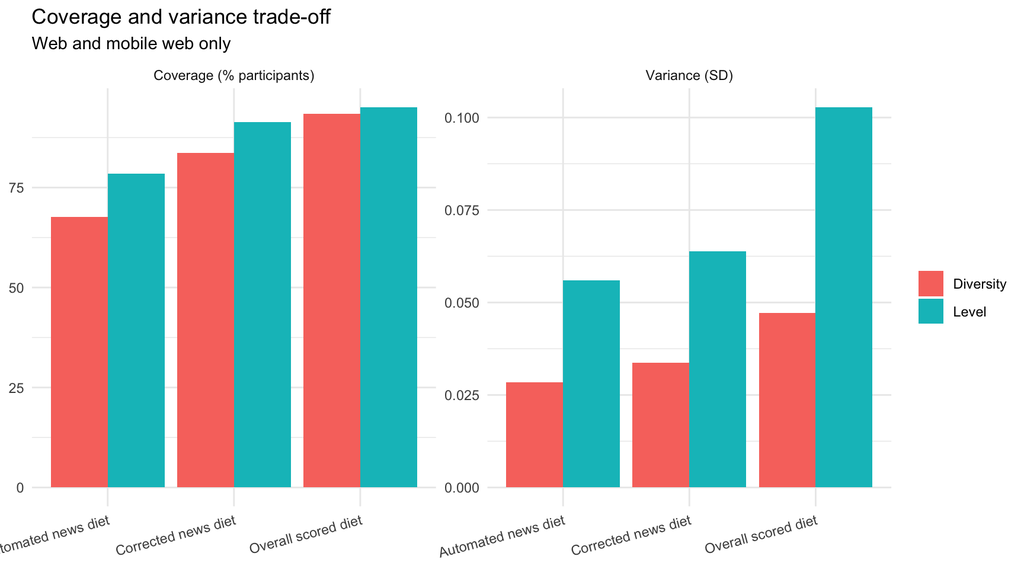

```r
plot_by_channel(
  variant_comparison %>%
    dplyr::select(channel, variant_label, pct_level_available,
                  pct_diversity_available, sd_level, sd_diversity) %>%
    pivot_longer(-c(channel, variant_label), names_to = "criterion", values_to = "value") %>%
    mutate(criterion_group = if_else(grepl("^pct_", criterion),
                                     "Coverage (% participants)", "Variance (SD)"),
           criterion = if_else(grepl("level", criterion), "Level", "Diversity")),
  function(d, lab)
    ggplot(d, aes(x = variant_label, y = value, fill = criterion)) +
      geom_col(position = "dodge") +
      facet_wrap(~ criterion_group, scales = "free_y") +
      labs(title = "Coverage and variance trade-off", subtitle = lab,
           x = NULL, y = NULL, fill = NULL) +
      theme_minimal() + theme(axis.text.x = element_text(angle = 15, hjust = 1)),
  "MAIN_plot_variant_comparison.png", width = 9, height = 5)
```

# 10 Final notes

| Analysis purpose | Variable in the wide file |
| --- | --- |
| Broad scored information diet | `hab_overall_dw_pc1`, `hab_overall_dw_sd_pc1` |
| Sensitivity to the automated coding | `hab_news_dw_pc1`, `hab_news_dw_sd_pc1` |
| Primary news-quality analysis | `hab_news_corrected_dw_pc1`, `hab_news_corrected_dw_sd_pc1` |
| Descriptive subgroup analysis only | `hab_<variant>_level_group`, `hab_<variant>_diversity_group`, `hab_<variant>_level_diversity_group` |
| App-traffic robustness | the same measures from the `without_apps` directory |

Every one of these is a **pre-treatment** measure. None of them may be used as an endogenous exposure or as a mediator in `03b`–`03e`; that role belongs to the `exp_` measures from `03a`.

Before using a news-specific diversity measure in a model, check `pct_diversity_available`. Diversity requires at least two distinct PC1 values among the relevant visits, so its sample can be smaller than the sample for level.